# Hands on GWAS in R

## 2.2 Assesing the Population Structure

- Population structure (PS) which includes ancestry differences or cryptic relatedness, can lead to spurious associatons if allele frequencies vary between subpopulations.
- Varous methods have been proposed and used to account for PS in GWAS stuudies. For more information on these methods and population structure please check these awesome papers: [Paper 1][https://www.nature.com/articles/nrg1916]; [Paper2](https://journals.plos.org/plosgenetics/article?id=10.1371/journal.pgen.0020190); [Paper 3](https://journals.plos.org/plosgenetics/article?id=10.1371/journal.pgen.1007309); [Paper 4](https://journals.plos.org/plosone/article?id=10.1371/journal.pone.0075707); [Paper 5](https://www.nature.com/articles/nrg2813); [Paper 6](https://link.springer.com/article/10.1007/s00439-019-02014-8)
- In genral PS can be corrected by incorporating the first few principal of genomic relationship matrix as fixed covariates in the GWAS model. However, with this approach, fitting few principal components may not be sufficient to account for complex population structure or family relatedness. Check this paper for more details [Paper](https://journals.plos.org/plosgenetics/article?id=10.1371/journal.pgen.1007309) -Alternatively, mixed model approach can be used in which the whole GRM can be included to account for relationships much better. For more details on this, check this [Paper](https://journals.plos.org/plosone/article?id=10.1371/journal.pone.0075707)
- In this section we will see how to check the PS using PCA. For that I will be using [SNPRelate](http://corearray.sourceforge.net/tutorials/SNPRelate/)

**Note**: Please note these methods are for demonstration purposes, latter you will see when we will perform GWAS, population structure can be automatically corrected.**

**Description of R Code**: * We will use filtered marker data file named as **Geno**. * First we will save the rownames (which are basically name of genotypes) and colnames (which are basically marker names).

- As most of the markers were dropped during pre-processing, it is required to match the name of markers with original map information file to make sure we have right marker names, there position and chromosome numbers which will required here.
- Then we will create a GDS formate file that is required for SNPRelate Package. For more information how to convert the various marker data formates into GDS formate please check this [link](http://corearray.sourceforge.net/tutorials/SNPRelate/#data-formats-used-in-snprelate).
- Finally we will perform PCA analysis and plot it. Importnatly, I highly reccomedn this paper ([Click here](https://academic.oup.com/bib/article-abstract/20/6/2200/5095727)to know more about the PCA in genetic data sets.
- Note: SNPRelate package has also one option to prune the SNPs based on LD between markers to avoid the clustering of same markers for more accurate PCA analysis. Please see this [link](http://corearray.sourceforge.net/tutorials/SNPRelate/#ld-based-snp-pruning) for more details.

```r
> # Save the name of genotypes which are given in rows of GENO file
>   names.genotypes<-rownames(Geno)
>   length(names.genotypes)
```

```
[1] 369
```

```r
> # Now save the name of markers which are given in columns of GENO
>   names.markers<-colnames(Geno)
>   length(names.markers)
```

```
[1] 33269
```

```r
> # Let us create GDS fomate file required for SNPRelate Package
>   snpgdsCreateGeno("geno.gds", genmat = Geno, sample.id =names.genotypes , snp.id=names.markers, snp.chromosome = MAP$V1, snp.position = MAP$V4, snpfirstdim = FALSE)
> # Now open this file
>   geno.gds <- snpgdsOpen("geno.gds")
> # check the summary to see if everything is correct.
>   snpgdsSummary("geno.gds")
```

[output not shown]

```r
> # Now let us perform the PCA analysis
>   pca.geno<- snpgdsPCA(geno.gds,
+                        snp.id = colnames(Geno), remove.monosnp=TRUE)
```

```
Principal Component Analysis (PCA) on genotypes:
Excluding 0 SNP (non-autosomes or non-selection)
Excluding 0 SNP (monomorphic: TRUE, MAF: NaN, missing rate: NaN)
    # of samples: 369
    # of SNPs: 33,269
    using 1 thread
    # of principal components: 32
PCA:    the sum of all selected genotypes (0,1,2) = 7255604
CPU capabilities: Double-Precision SSE2
Fri Oct  7 20:52:01 2022    (internal increment: 1320)

[..................................................]  0%, ETC: ---
[==================================================] 100%, completed, 3s
Fri Oct  7 20:52:04 2022    Begin (eigenvalues and eigenvectors)
Fri Oct  7 20:52:04 2022    Done.
```

```r
> # Here we can also filter for missing and MAF if needed. Check arguments.
> # Variance proportion
>   head(round(pca.geno$varprop*100,2))
```

```
[1] 36.52 10.61  6.28  2.13  1.66  1.42
```

```r
> # Let us extract the PC components and save it as csv
>   pca.data<- data.frame(sample.id = pca.geno$sample.id,
+                       EV1 = pca.geno$eigenvect[,1],    # the first eigenvector
+                       EV2 = pca.geno$eigenvect[,2],    # the second eigenvector
+                       EV3 = pca.geno$eigenvect[,3],
+                       EV4 = pca.geno$eigenvect[,4],
+                       EV5 = pca.geno$eigenvect[,5],
+                       stringsAsFactors = FALSE)
>   head(pca.data)
```

```
  sample.id          EV1          EV2          EV3           EV4           EV5
1   NSFTV_1  0.051361386 -0.004272408 -0.083829464 -0.0094438157 -0.0050061938
2   NSFTV_3 -0.074069809  0.085859549 -0.011662966  0.0007424995  0.0900502054
3   NSFTV_4 -0.061047381 -0.069553050  0.006703113 -0.0431206810  0.0331544631
4   NSFTV_5  0.006242069 -0.021963559  0.009926203  0.2951821890 -0.0003891396
5   NSFTV_6 -0.057366888 -0.067255883  0.006436550 -0.0446261025  0.0328013635
6   NSFTV_7  0.030416205  0.002926056  0.070855304 -0.0049502083  0.0184419743
```

```r
> # Add the population information to pca.data file.
> # Borrowing the population information from pca data file available on web.
> # Read pca file from web and save it as pca.webdata
>   pca.webdata<- read.csv("http://ricediversity.org/data/sets/44kgwas/RiceDiversity.44K.germplasm.csv", header = TRUE, skip = 1, stringsAsFactors = FALSE)  # 431 x 12
> # Chnage the name formate of the genotypes by pasting "NSFTV_ID_" to each line
>   pca.webdata$NSFTV.ID<-paste0("NSFTV_", pca.webdata$NSFTV.ID)
> # Now let us match this file with our file pca.data file.
>   pca.webdata<- pca.webdata[match(pca.data$sample.id,
+                                   pca.webdata$NSFTV.ID), ]
>   table(pca.data$sample.id == pca.webdata$NSFTV.ID)
```

```
TRUE
 369
```

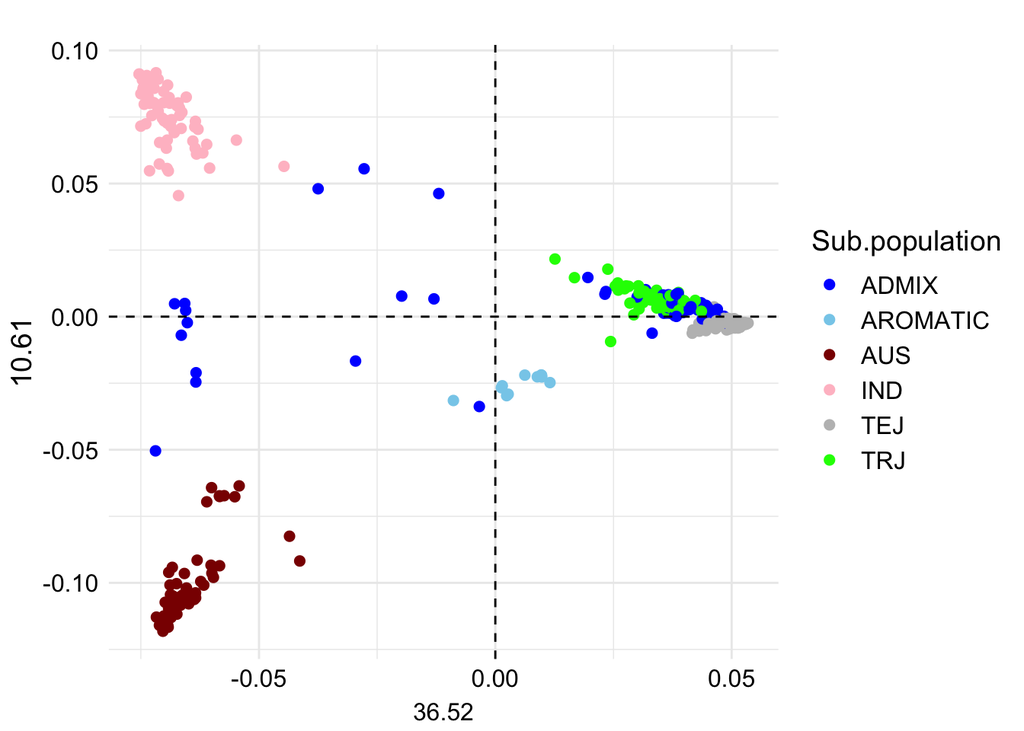

```r
> # here we will check wether the names are similar.
>
> # Now let us add this population information to our pca.data file
>   pca.data <- cbind(pca.webdata$Sub.population, pca.data)
>   colnames(pca.data)[1] <- "Sub.population" # rename first column
> # Save the pca file in output directory
> #write.csv(pca.data, file="./outputfiles/PCA/pca.data.csv",row.names = FALSE)
> # Visualize the PCA plot using ggplot.
>   ggplot(pca.data,aes(x=EV1,y=EV2, color=Sub.population))+
+   geom_point(size=2)+
+     geom_hline(yintercept=0.00, linetype="dashed", color = "black")+
+     geom_vline(xintercept=0.00, linetype="dashed", color = "black")+
+     theme_minimal()+
+     scale_color_manual(values = c("blue", "skyblue", "darkred", "pink", "gray", "green"))+
+     labs(title = "", x=paste(round((pca.geno$varprop*100)[1],2)),y=paste(round((pca.geno$varprop*100)[2],2)))+ # here adding varaince contribution to x and y-axis.
+     theme(plot.title = element_text(color="black",size=12, hjust=0.5))+
+   theme(axis.text.x=element_text(colour='black', size=12)) + #asthetics of x-axis text
+   theme(axis.text.y=element_text(colour='black', size=12)) + #asthetics of y-axis text
+   theme(axis.title.x = element_text(colour='black', size=12, vjust=0.0)) + #asthetics of x-axis title
+   theme(axis.title.y = element_text(colour='black', size=14))+
+   theme(legend.title = element_text(colour="black", size=14),
+         legend.text = element_text(colour="grey0", size=12))+
+   guides(fill=guide_legend(title="Sub Populations"))
```